Den otevřených dveří

ČVUT v Praze

# Katedra matematiky

Fakulta jaderná a fyzikálně inženýrská

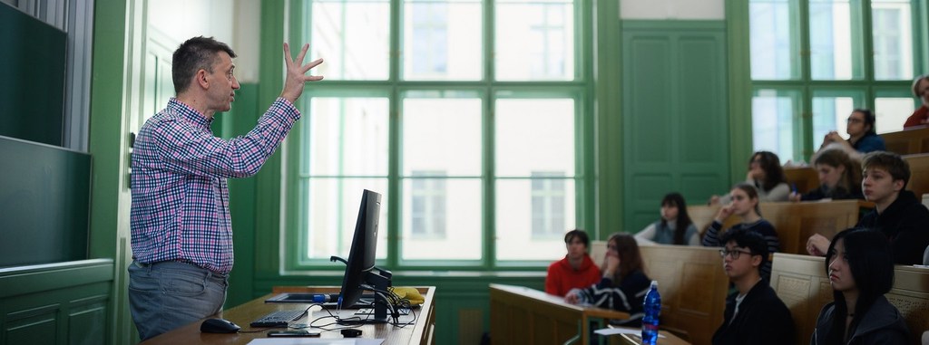

Výuka matematiky na Jaderce

Lidé a výzkum

## Čtyři výzkumné skupiny

Každá skupina řeší řadu témat. Podívejte se na několik příkladů.

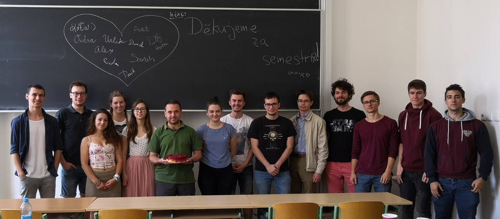

Studenti katedry v posluchárně

Bakalářské studium · 3 roky

## Co studovat?

- **Aplikovaná algebra a analýza**Matice, rovnice a důkazy při řešení praktických úloh.
- **Aplikované matematicko-stochastické metody**Statistika a modelování jevů, ve kterých hraje roli náhoda.
- **Matematické inženýrství**Společný základ z matematiky, fyziky a programování.

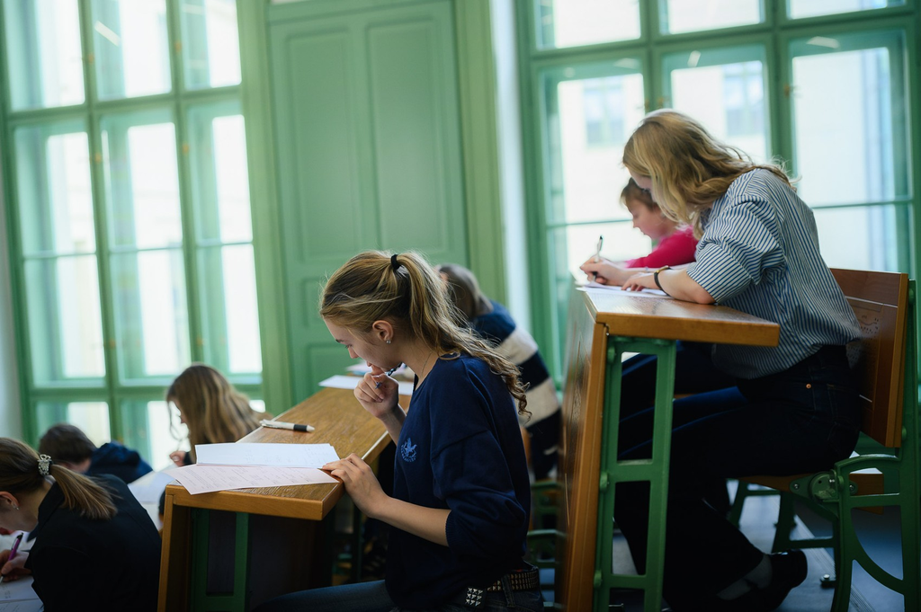

### Tři specializace Matematického inženýrství

- **Matematické modelování**Simulace proudění, šíření látek nebo růstu materiálů.
- **Matematická fyzika**Geometrie a algebra pro popis kvantových jevů.
- **Matematická informatika**Jak navrhovat algoritmy a určovat jejich složitost.

GAMS · Ukázka výzkumu

## Kolik místa si nechávají řidiči na červenou?

Milan Krbálek měřil mezery mezi auty na pražských křižovatkách. Zkoumal, jak často řidiči zastaví těsně za sebou a jak často nechají větší odstup.

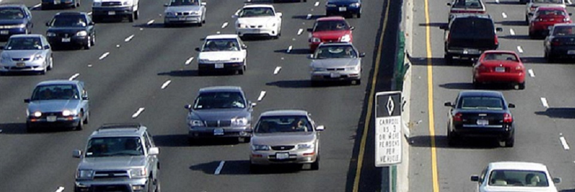

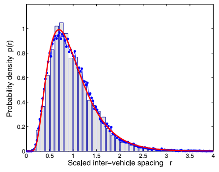

**Rozestupy v koloně**Sloupce ukazují měření, červená křivka model. Na vodorovné ose odpovídá 1 průměrné mezeře.

MMG · Ukázka výzkumu

## Krev v aortě

Tvar aorty získáme z magnetické rezonance. Barevné proudnice ukazují, jak v ní teče krev.

[figure not shown]

Měření průtoku v modelu cévy v IKEM

[video not shown]

TIGR · Ukázka výzkumu

## Dva tvary, nekonečně mnoho dlaždic

Dva druhy kosočtverců pokryjí celou rovinu. Posuneme-li vzor jakýmkoli směrem o nenulovou vzdálenost, nikdy se s původním vzorem přesně nekryje.

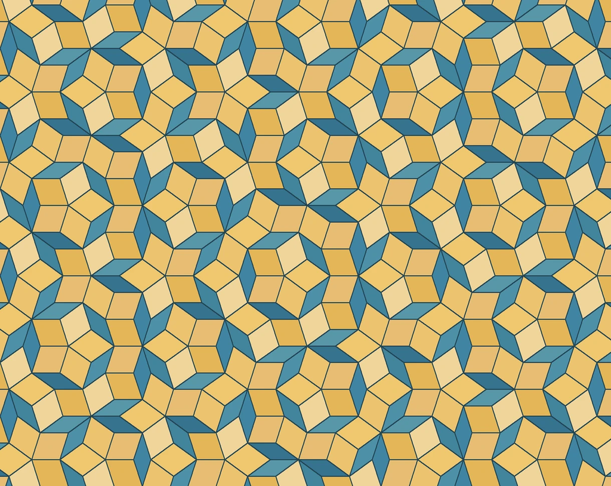

Penroseovo dláždění dvěma druhy kosočtverců

MAFIA · Ukázka výzkumu

## Jak kmitá napnutá membrána?

Při různých frekvencích vznikají různé tvary kmitů. Mezi sousedními kmitnami zůstává membrána v klidu.

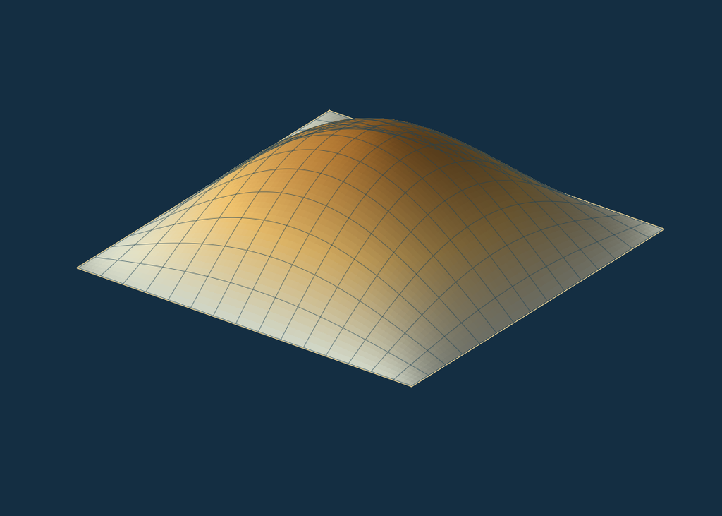

Výchylka čtvercové membrány s pevným okrajem

Výzkum na katedře

## Co dalšího skupiny zkoumají?

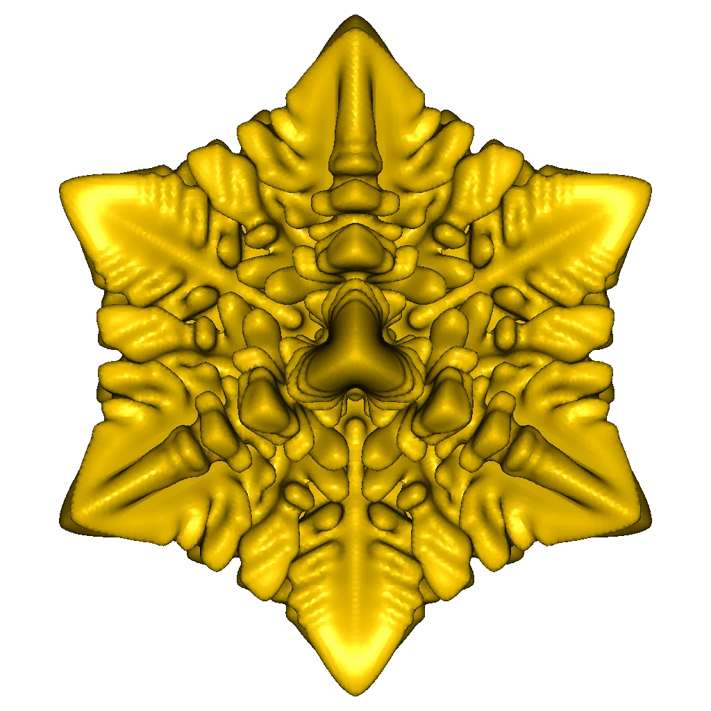

MMG

### Růst krystalů

Jak při tuhnutí kovu vznikají větvená ramena?

[figure not shown]

GAMS

### Pohyb chodců

Jak rychle projde dav úzkými dveřmi?

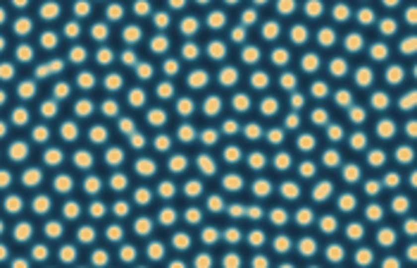

MAFIA

### Vznik skvrn

Jak z původně rovnoměrného rozložení látek vznikne vzor?

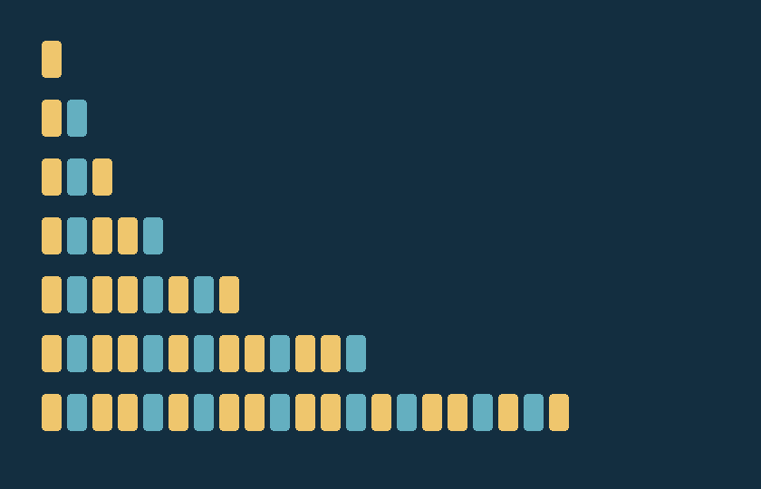

TIGR

### Fibonacciho slovo

Žlutá 0 se mění na 01, modrá 1 na 0. Každý řádek je o krok dál.

Navazující magisterské studium · 2 roky

## Kam po bakaláři?

- **Aplikovaná algebra a analýza**Algebraické struktury, operátory a jejich využití ve fyzice.
- **Aplikované matematicko-stochastické metody**Odhady z dat a pravděpodobnostní modely složitých systémů.
- **Matematická informatika**Diskrétní matematika, algoritmy a teoretické základy informatiky.
- **Matematické inženýrství**Numerické simulace a paralelní výpočty v přírodních vědách.
- **Učitelství matematiky pro střední školy**Didaktika, psychologie a praxe ve výuce matematiky.

[figure not shown]

Den otevřených dveří v Trojanově ulici

Doktorské studium · 4 roky

## Matematické inženýrství

Vlastní výzkum v jednom ze tří zaměření.

- **Matematické modelování**Modely přírodních a technických dějů.
- **Matematická fyzika**Matematický popis kvantových systémů.
- **Softwarové inženýrství**Algoritmy pro analýzu vědeckých dat.

[figure not shown]

První doktorandi programu PICTUS na ČVUT, 2026

[figure not shown]

Studijní programy a podrobnosti**km.fjfi.cvut.cz**